# Movie Recommendation

We will use the following libraries for this project:

```r
library(tidyverse) # for tidy data
library(gridExtra) # to plot graphs in a grid, or next to each other
library(dplyr) # for data manipulation
library(ggplot2) #for visualisations
library(caret) # for ML, resampling and model training
library(dslabs) # for the movielens data
data("movielens") # load-up the movielens data
```

## Examination & Preparation

Next, carry out preliminary examination of the data:

```r
dim(movielens)
```

```
[1] 100004      7
```

This dataset has 100,004 rows and 7 columns.

```r
head(movielens)
```

|  | movieId | title | year | genres | userId | rating | timestamp |
| --- | --- | --- | --- | --- | --- | --- | --- |
| 1 | 31 | Dangerous Minds | 1995 | Drama | 1 | 2.5 | 1260759144 |
| 2 | 1029 | Dumbo | 1941 | Animation\|Children\|Drama\|Musical | 1 | 3.0 | 1260759179 |
| 3 | 1061 | Sleepers | 1996 | Thriller | 1 | 3.0 | 1260759182 |
| 4 | 1129 | Escape from New York | 1981 | Action\|Adventure\|Sci-Fi\|Thriller | 1 | 2.0 | 1260759185 |
| 5 | 1172 | Cinema Paradiso (Nuovo cinema Paradiso) | 1989 | Drama | 1 | 4.0 | 1260759205 |
| 6 | 1263 | Deer Hunter, The | 1978 | Drama\|War | 1 | 2.0 | 1260759151 |

The table is in a tidy format with each row representing a rating given by one user to one movie.

Lets check how many users have provided ratings and how many movies were rated:

```r
#create a table summarising the total numbers of users and movies. Use the n_distinct() function and not count() as the latter will only give the number of times that user has given a rating.
movielens %>% summarise(n_users = n_distinct(userId),
                        n_movies = n_distinct(movieId))
```

| n_users | n_movies |
| --- | --- |
| 671 | 9066 |

So there are 671 users and 9066 movies. This does not add-up. 671 x 9066 = 6,083,286. Yet there are only 100,004 rows. The only explanation is that not every user rated every movie.

Since that is the case, if we imagine a matrix where rows are users and columns are movies (or vice versa) there would be a lot of empty cells.

The gather() function, or alternatively pivot_wider() function allows us to convert to this format, but if we try it for the entire 671x9066 matrix, it will crash R. So let’s look at the matrix for 7 users and top 5 most rated movies:

```r
#to identify the top 5 movies first use count() function to count unique number of movies using their Id numbers, and then select the top 5 by using the top_n() function. Both functions are from the dplyr package
keep <- movielens %>%
  count(movieId) %>%
  top_n(5) %>%
  pull(movieId)
#choose 7 random users, in this case lets say users from 13 to 20, and create a tidy matrix

tab <- movielens %>%
  filter(userId %in% c(13:20)) %>%
  filter(movieId %in% keep) %>%
  select(userId, title, rating) %>%
  #spread(title, rating)
  pivot_wider(names_from = title,
              values_from = rating) #if we don't use pivot_wider() function (this function supersedes spread() function that was previously used) from the tidyr package the resulting matrix will have the same output format as movielens - ie, each row represents one rating given by one user to one movie. This means, without spread, rows would list users and their ratings for each movie before doing the same for the next user so on.
tab
```

| userId | Pulp Fiction | Shawshank Redemption, The | Forrest Gump | Star Wars: Episode IV - A New Hope | Silence of the Lambs, The |
| --- | --- | --- | --- | --- | --- |
| 13 | 3.5 | 4.5 | 5.0 | NA | NA |
| 15 | 5.0 | 2.0 | 1.0 | 5.0 | 5.0 |
| 16 | NA | 4.0 | NA | NA | NA |
| 17 | 5.0 | 5.0 | 2.5 | 3.5 | 4.5 |
| 18 | NA | NA | NA | 3.0 | NA |
| 19 | 5.0 | 4.0 | 5.0 | 4.0 | 3.0 |
| 20 | 0.5 | 4.5 | 2.0 | 1.5 | 0.5 |

As can be seen there are NAs present.

The task of recommendation system can be thought of as filling in the NAs in this matrix. We can also visualise where NAs are in the matrix. Lets try a visualisation for a random sample of 100 movies and 100 users:

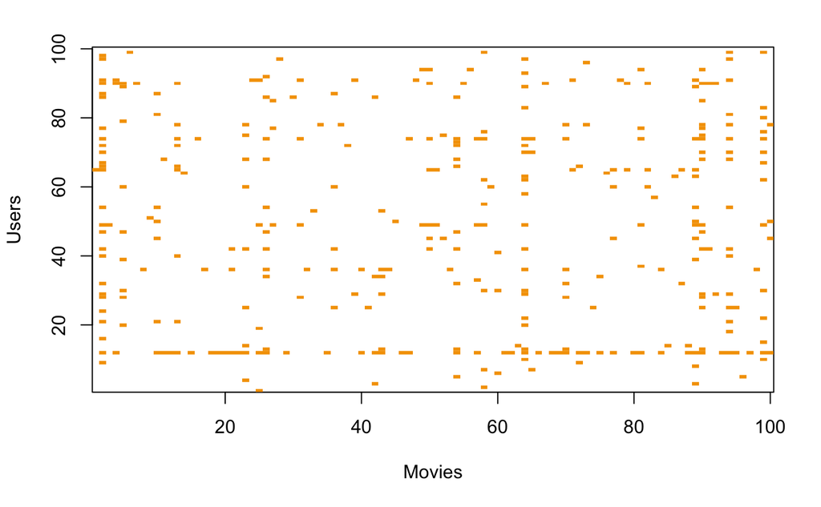

```r
#randomly select 100 users

users <- sample(unique(movielens$userId), 100)

movielens %>%
  filter(userId %in% users) %>%
  select (userId, movieId, rating) %>%
  mutate(rating = 1) %>% #changes all the assigned ratings to 1. Choice of 1 is arbitrary so long as long as they are uniform so that the image can show the contrast between NAs and those that received a rating of any value.
  pivot_wider(names_from = movieId, values_from = rating) %>%
  select(sample(ncol(.), 100)) %>%
  as.matrix() %>%
  t(.) %>% # this transposes the matrix so that movieIds are the rows and users are the columns
  image(1:100, 1:100, . , xlab = "Movies", ylab = "Users")
```

Now we can start trying to make some predictions.

There are some complications that need to be expressed from the outset. Note that each outcome Y has a different set of predictors. In other words, to predict rating for movie i by user u, in principle we should be able to use as predictors all other ratings related to movie i and by user u. However, the complicating issue is that different users rate different movies, and they rate different number of movies. It may also be the case that we may be able to see info from other movies that we determine to be similar to movie i, or from users determined to be similar to user u. In essence, the entire matrix can be used as predictors for each cell.

Lets look at some of the general properties of the data to better understand the challenges.

We would expect some movies to get rated a lot more than some others - think of a blockbuster vs some obscure movie. We would also expect some users to be more active in rating movies than others. We can check these with histograms:

```r
# Histogram for movies assigned to p1
p1 <- movielens %>%
  count(movieId) %>%
  ggplot(aes(n)) +
  geom_histogram(bins = 30,
                 colour = "black") +
  scale_x_log10() +
  ggtitle("Movies")

#Histogram for users assigned to p2
p2 <- movielens %>%
  count(userId) %>%
  ggplot(aes(n)) +
  geom_histogram(bins = 30,
                 colour = "black") +
  scale_x_log10() +
  ggtitle("Users")

#arrange p1 and p2 in grid formation
grid.arrange(p1, p2, ncol = 2)
```

[output not shown]

Our expectations are confirmed - some movies receive a lot more ratings, and some users are a lot more active than the others.

Our main goal is to build an algorithm with data we have collected that will then be applied outside our control - movie recommendations for users.

As a 1st step, lets create a test set to assess the accuracy of the models we implement.

```r
set.seed(755) #for reproduceability

#1st step:use createDataPartition from caret package to partition the ratings
test_index <- createDataPartition(y = movielens$rating,
                                  times = 1,
                                  p = 0.2,
                                  list = FALSE)

#2nd step: assign the partitioned data to training and test sets
train_set <- movielens[-test_index, ]
test_set <- movielens[test_index, ]
```

If we leave it like this, then there is a chance that some users and movies that are in the training set are not in the test set and vice versa. Since that would not be helpful for our predictions, we need to remove those entries using the semi_join function:

```r
test_set <- test_set %>%
  semi_join(train_set, by = "movieId") %>%
  semi_join(train_set, by = "userId")
```

### Definition of Success: Loss Function

To compare different models or to see how we are doing compared to some baseline, we need to quantify what it means to do well. So we need a loss function.

The Netflix challenge used the typical error loss: they decided on a winner based on the residual mean squared error (RMSE) on a test set. We define $y_{u,i}$ as the rating for movie $i$ by user $u$ and denote our prediction with $\hat{y}_{u,i}$. The RMSE is then defined as:

$$\mbox{RMSE} = \sqrt{\frac{1}{N} \sum_{u,i}^{} \left( \hat{y}_{u,i} -
y_{u,i} \right)^2 }$$

with $N$ being the number of user/movie combinations and the sum occurring over all these combinations.

Remember that we can interpret the RMSE similarly to a standard deviation: it is the typical error we make when predicting a movie rating. If this number is larger than 1, it means our typical error is larger than one star, which is not good.

Let’s write a function that computes the RMSE for vectors of ratings and their corresponding predictors:

```r
#function to compare models' RMSEs using the above formula

RMSE <- function(true_ratings, predicted_ratings){
  sqrt(mean((true_ratings - predicted_ratings)^2))
}
```

Now we are ready to build models & compare them to each other.

## Models

The Netflix challenge winners implemented two general classes of models. –> One similar to kNN –> Matrix factorisation (main focus of this project)

### 1st Model: Establishing the base to compare models against

Let’s start by building the simplest possible recommendation system: we predict the same rating for all movies regardless of user. What number should this prediction be? We can use a model based approach to answer this. A model that assumes the same rating for all movies and users with all the differences explained by random variation would look like this:

$$Y_{u,i} = \mu + \varepsilon_{u,i}$$

with $\varepsilon_{i,u}$ independent errors sampled from the same distribution centered at 0 and $\mu$ the “true” rating for all movies. We know that the estimate that minimizes the RMSE is the least squares estimate of $\mu$ and, in this case, is the average of all ratings:

```r
#set average of all ratings as our estimate of mu
rating_avg <- mean(train_set$rating)
rating_avg
```

```
[1] 3.543305
```

So we would predict an average rating of 3.54 for all movies regardless of user. If this is our prediction, then our RMSE for this prediction would be:

```r
#use the RMSE function we just created above and assign it to naive_RMSE
naive_RMSE <- RMSE(test_set$rating, rating_avg)
naive_RMSE
```

```
[1] 1.052805
```

The RMSE of our naive model is about 1.05.From looking at the distribution of ratings, we can visualize that this is the standard deviation of that distribution. We get a RMSE of about 1. To win the grand prize of $1,000,000, a participating team had to get an RMSE of about 0.857. So we can definitely do better than 1.05.

As we go along, we will be comparing different approaches. Let’s start by creating a results table with this naive approach:

```r
#we can use tibble for creating the results table

rmse_results <- tibble("Naive: Just the Average", naive_RMSE) %>%
  set_names(c("method", "RMSE")) #set names add column names. This is needed for us to use bind_rows() function later on to add more rows with results from our other models
rmse_results
```

| method | RMSE |
| --- | --- |
| Naive: Just the Average | 1.052805 |

### 2nd Model: Adding movie effects

We know from above and from data that some movies are generally rated higher than others (blockbuster vs obscure). To incorporate this into our model we add the term b_i to represent average ranking for movie i.

$$Y_{u,i} = \mu + b_i + \varepsilon_{u,i}$$

Statistics textbooks refer to the $b$s as effects. However, in the Netflix challenge papers, they refer to them as “bias”, thus the $b$ notation.

We can use least squares to estimate the $b_i$ with lm(rating ~ as.factor(movieId), data = movielens) but this function would be very slow because there are thousands of $b_i$ since each movie gets one.

Instead, in this particular situation, we know that the least squares estimate $\hat{b}_i$ is just the average of $Y_{u,i} - \hat{\mu}$ for each movie $i$.
$$Y_{u,i} = \mu + b_i + \varepsilon_{u,i}$$
$$b_i = Y_{u,i} - \mu + \varepsilon_{u,i}$$

So we can compute them this way

```r
movie_avgs <- train_set %>%
  group_by(movieId) %>%
  summarise(b_i = mean(rating - rating_avg))
head(movie_avgs)
```

| movieId | b_i |
| --- | --- |
| 1 | 0.3163007 |
| 2 | -0.1367118 |
| 3 | -0.2063486 |
| 4 | -1.1933052 |
| 5 | -0.1846095 |
| 6 | 0.3449301 |

We can plot movie averages to see the variation in estimates:

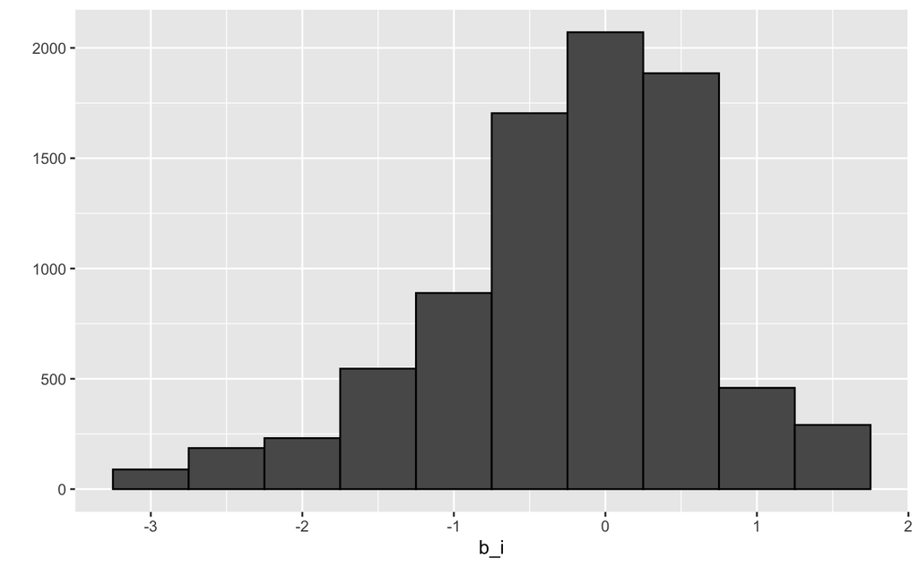

Remember our rating average is 3.5 as calculated above ($\hat{\mu}=3.5$), so a $b_i = 1.5$ implies a perfect five star rating, and a $b_i = -3$ implies a rating of half a star.

Let’s see how much our prediction improves once we use $\hat{y}_{u,i} = \hat{\mu} + \hat{b}_i$:

```r
#we can check the performance of this model using our RMSE function:
RMSE(predicted_ratings, test_set$rating)
```

```
[1] 0.9885931
```

We can see that we have improved our accuracy from 1.05 to just below 0.99. Lets add this to our results table:

```r
movie_effect_model_rmse <- RMSE(predicted_ratings, test_set$rating)

#we will use bind_rows() from dplyr package to add the movie effect model's RMSE to our table. This function binds two data frames by rows.
rmse_results <- bind_rows(rmse_results,
                          tibble(method = "Movie Effect Model",
                                 RMSE = movie_effect_model_rmse))
rmse_results
```

| method | RMSE |
| --- | --- |
| Naive: Just the Average | 1.0528047 |
| Movie Effect Model | 0.9885931 |

This improvement was due to incorporating movie effects. Lets see if we can similarly incorporate user effects, and whether that would further improve our prediction.

### 3rd Model: Adding user effects

User effect refers to the idea that different users have different tastes and so they differ in how they rate movies.

To see if our assumption holds by the data, we should explore the data by computing the average rating for user $u$, and lets limit it to those that have rated at least 100 movies.

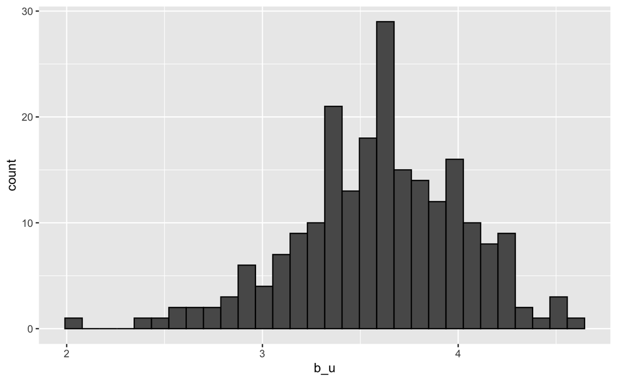

```r
#create histogram of user effect

train_set %>%
  group_by(userId) %>%
  filter(n() >= 100) %>%
  summarise(b_u = mean(rating)) %>%
  ggplot(aes(b_u)) +
  geom_histogram(bins = 30, colour = "black")
```

We can see that some users that rated at least 100 movies are a bit cranky with low average ratings, and some love almost every movie. So there is a lot of variability among the users.

This implies that a further improvement to our model may be:

$$Y_{u,i} = \mu + b_i + b_u + \varepsilon_{u,i}$$

where $b_u$ is a user-specific effect. Now if a cranky user (negative $b_u$) rates a great movie (positive $b_i$), the effects counter each other and we may be able to correctly predict that this user gave this great movie a 3 rather than a 5.

To fit this model, we could again use lm(rating ~ as.factor(movieId) + as.factor(userId)) but for computational time reasons we won’t.

Instead, we will compute an approximation by computing $\hat{\mu}$ and $\hat{b}_i$ and estimating $\hat{b}_u$ as the average of
$$y_{u,i} - \hat{\mu} - \hat{b}_i$$

```r
user_avgs <- train_set %>%
  left_join(movie_avgs, by= "movieId") %>% #adding movie averages to the training set
  group_by(userId) %>%
  summarise(b_u = mean(rating - rating_avg - b_i))
head(user_avgs)
```

| userId | b_u |
| --- | --- |
| 1 | -0.89583512 |
| 2 | -0.07038863 |
| 3 | -0.16676110 |
| 4 | 0.71918620 |
| 5 | 0.39482769 |
| 6 | -0.36584612 |

We can now construct predictors and see how much the RMSE improves:

```r
predicted_ratings <- test_set %>%
  left_join(movie_avgs, by="movieId") %>%
  left_join(user_avgs, by="userId") %>%
  mutate(pred = rating_avg + b_i + b_u) %>%
  .$pred #or pull(pred)

#calculate the RMSE
movie_and_user_effect_rmse <- RMSE(test_set$rating, predicted_ratings)

#add the rmse to the results table
rmse_results <- bind_rows(rmse_results,
                          tibble(method = "Movie & User Effects Model",
                                 RMSE = movie_and_user_effect_rmse))
rmse_results
```

| method | RMSE |
| --- | --- |
| Naive: Just the Average | 1.0528047 |
| Movie Effect Model | 0.9885931 |
| Movie & User Effects Model | 0.9049899 |

We see an improved RMSE at about 0.905 now. Our only movie effect model had about 6% improvement (from 1.05 to 0.988). We should pause and check where we made mistakes. We can first check the top 10 mistakes we made with movie effect, $b_i$, only. The mistakes can be identified by look at the residuals which is equal to the difference between actual rating in test set and our prediction ($mu_hat$ + $b_i$)

```r
test_set %>%
  left_join(movie_avgs, by="movieId") %>%
  mutate(residual = rating - (rating_avg + b_i)) %>%
  arrange(desc(abs(residual))) %>% #although arrange(residual) gives the same answer, note the logic of it. residuals can be in either direction, so taking the absolute values and then sorting them in descending order is the logic behind this arrangement.
  slice(1:10)
```

| movieId | title | year | genres | userId | rating | timestamp | b_i | residual |
| --- | --- | --- | --- | --- | --- | --- | --- | --- |
| 7505 | Kingdom, The (Riget) | 1994 | Drama\|Horror\|Mystery | 394 | 0.5 | 1297603192 | 0.9566948 | -4.000000 |
| 6450 | Heaven Knows, Mr. Allison | 1957 | Drama\|War | 452 | 0.5 | 1067731764 | 0.9566948 | -4.000000 |
| 3718 | American Pimp | 1999 | Documentary | 609 | 1.0 | 1029869615 | 1.4566948 | -4.000000 |
| 1252 | Chinatown | 1974 | Crime\|Film-Noir\|Mystery\|Thriller | 174 | 0.5 | 1109621175 | 0.7870520 | -3.830357 |
| 2858 | American Beauty | 1999 | Drama\|Romance | 405 | 0.5 | 1061362675 | 0.6957058 | -3.739011 |
| 1208 | Apocalypse Now | 1979 | Action\|Drama\|War | 607 | 0.5 | 1153513594 | 0.6861066 | -3.729412 |
| 111 | Taxi Driver | 1976 | Crime\|Drama\|Thriller | 133 | 0.5 | 1416151676 | 0.6709805 | -3.714286 |
| 745 | Wallace & Gromit: A Close Shave | 1995 | Animation\|Children\|Comedy | 133 | 0.5 | 1416152168 | 0.6527733 | -3.696078 |
| 2434 | Down in the Delta | 1998 | Drama | 609 | 1.0 | 1029869914 | 1.1233615 | -3.666667 |
| 3196 | Stalag 17 | 1953 | Drama\|War | 20 | 0.5 | 1238729331 | 0.6037537 | -3.647059 |

There are some obscure and some known movies in the top10 mistakes list. It may be that there are not many ratings for these so our $b_i$ may be error prone. We can look at the top 10 best and worst movies based only on $\hat{b}_i$ and see how many times these movies have been rated. To do so, First, let’s create a database that connects `movieId` to movie title

```r
movie_titles <- movielens %>%
  select(movieId, title) %>%
  distinct()
```

Here are the 10 best movies according to our estimate:

```r
movie_avgs %>%
  left_join(movie_titles, by="movieId") %>%
  arrange(desc(b_i)) %>%
  slice(1:10) %>%
  .$title
```

```
 [1] "When Night Is Falling"                                   "Lamerica"
 [3] "Mute Witness"                                            "Picture Bride (Bijo photo)"
 [5] "Red Firecracker, Green Firecracker (Pao Da Shuang Deng)" "Paris, France"
 [7] "Faces"                                                   "Maya Lin: A Strong Clear Vision"
 [9] "Heavy"                                                   "Gate of Heavenly Peace, The"
```

and here are the 10 worst:

```r
movie_avgs %>%
  left_join(movie_titles, by="movieId") %>%
  arrange(b_i) %>%
  slice(1:10) %>%
  .$title
```

```
 [1] "Children of the Corn IV: The Gathering"            "Barney's Great Adventure"
 [3] "Merry War, A"                                      "Whiteboyz"
 [5] "Catfish in Black Bean Sauce"                       "Killer Shrews, The"
 [7] "Horrors of Spider Island (Ein Toter Hing im Netz)" "Monkeybone"
 [9] "Arthur 2: On the Rocks"                            "Red Heat"
```

They all seem quite obscure. let’s see how often they have been rated actually

```r
train_set %>%
  count(movieId) %>%
  left_join(movie_avgs) %>%
  left_join(movie_titles, by="movieId") %>%
  arrange(desc(b_i)) %>%
  slice(1:10) %>%
  pull(n)
```

```
 [1] 1 1 1 1 3 1 1 2 1 1
```

These movies we estimated to be the top 10 best and worst movies were actually rated by very few users, in most cases just 1. This is because with just a few users, we have more uncertainty. Therefore, larger estimates of $b_i$, negative or positive, are more likely.

These are noisy estimates that we should not trust, especially when it comes to prediction. Large errors can increase our RMSE, so we would rather be conservative when unsure.

Usually, when we are accounting for uncertainty we would usually use confidence intervals. However, when making predictions, we need one number, one prediction, not an interval. For this, we introduce the concept of regularization.

## Regularisation

Regularisation permits us to penalize large estimates that are formed using small sample sizes. It has commonalities with the Bayesian approach that shrunk predictions. It was one of the techniques that was used by the winners of Netflix Challenge.

The general idea behind regularization is to constrain the total variability of the effect sizes. We are just adding a penalty for large values of $b$ to the sum of squares equations that we want to minimise. Specifically, instead of minimising the least squares equation, we minimize an equation that adds a penalty.

$$\sum_{u,i} \left(y_{u,i} - \mu - b_i\right)^2 + \lambda \sum_{i} b_i^2$$
The first term is just the sum of squares and the second is a penalty that gets larger when many $b_i$ are large. Using calculus we can actually show that the values of $b_i$ that minimize this equation are:

$$\hat{b}_i(\lambda) = \frac{1}{\lambda + n_i} \sum_{u=1}^{n_i}
\left(Y_{u,i} - \hat{\mu}\right)$$

where $n_i$ is the number of ratings made for movie $i$. This approach will have our desired effect: when our sample size $n_i$ is very large, a case which will give us a stable estimate, then the penalty $\lambda$ is effectively ignored since $n_i+\lambda \approx n_i$. However, when the $n_i$ is small, then the estimate $\hat{b}_i(\lambda)$ is shrunken towards 0. The larger $\lambda$, the more we shrink.

Let’s compute these regularised estimates of $b_i$ using $\lambda=3$. Later, we will see why we picked 3.

```r
lambda <- 3
movie_reg_avgs <- train_set %>%
  group_by(movieId) %>%
  summarise(b_i = sum(rating - rating_avg) / (n() + lambda),
            n_i = n())
```

To see how the estimates shrink, let’s make a plot of the regularized estimates versus the least squares estimates. The sizes of the circlues in the graph tells us how large $n_i$ was:

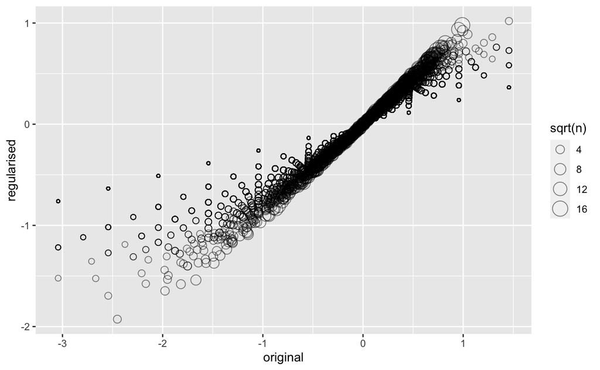

```r
tibble(original = movie_avgs$b_i,
       regularised = movie_reg_avgs$b_i,
       n = movie_reg_avgs$n_i) %>%
  ggplot(aes(original, regularised, size = sqrt(n))) +
  geom_point(shape = 1, alpha = 0.5)
```

From the plot it can be seen that as n gets smaller, the values tend towards 0.

Now lets look at the top 10 best movies based on the penalised estimates $\hat{b}_i(\lambda)$:

```r
train_set %>%
  count(movieId) %>%
  left_join(movie_reg_avgs, by = "movieId") %>%
  left_join(movie_titles, by = "movieId") %>%
  arrange(desc(b_i)) %>%
  slice(1:10) %>%
  pull(title)
```

```
 [1] "Paris Is Burning"          "Shawshank Redemption, The" "Godfather, The"            "African Queen, The"
 [5] "Band of Brothers"          "Paperman"                  "On the Waterfront"         "All About Eve"
 [9] "Usual Suspects, The"       "Ikiru"
```

These make much more sense! These movies are watched more and have more ratings. Here are the top 10 worst movies:

```r
train_set %>%
  count(movieId) %>%
  left_join(movie_reg_avgs, by = "movieId") %>%
  left_join(movie_titles, by="movieId") %>%
  arrange(b_i) %>%
  select(title, b_i, n) %>%
  slice(1:10) %>%
  pull(title)
```

```
 [1] "Battlefield Earth"                       "Joe's Apartment"
 [3] "Super Mario Bros."                       "Speed 2: Cruise Control"
 [5] "Dungeons & Dragons"                      "Batman & Robin"
 [7] "Police Academy 6: City Under Siege"      "Cats & Dogs"
 [9] "Disaster Movie"                          "Mighty Morphin Power Rangers: The Movie"
```

We can now check if we improved our results:

| method | RMSE |
| --- | --- |
| Naive: Just the Average | 1.0528047 |
| Movie Effect Model | 0.9885931 |
| Movie & User Effects Model | 0.9049899 |
| Regularised Movie Effect Model | 0.9699530 |

We see that regularisation has improved movie effect RMSE from 0.988 to 0.97.

Of course, we set lambda to 3 above. However, lambda is a tuning parameter, so we can use cross validation to choose the best penalty to apply:

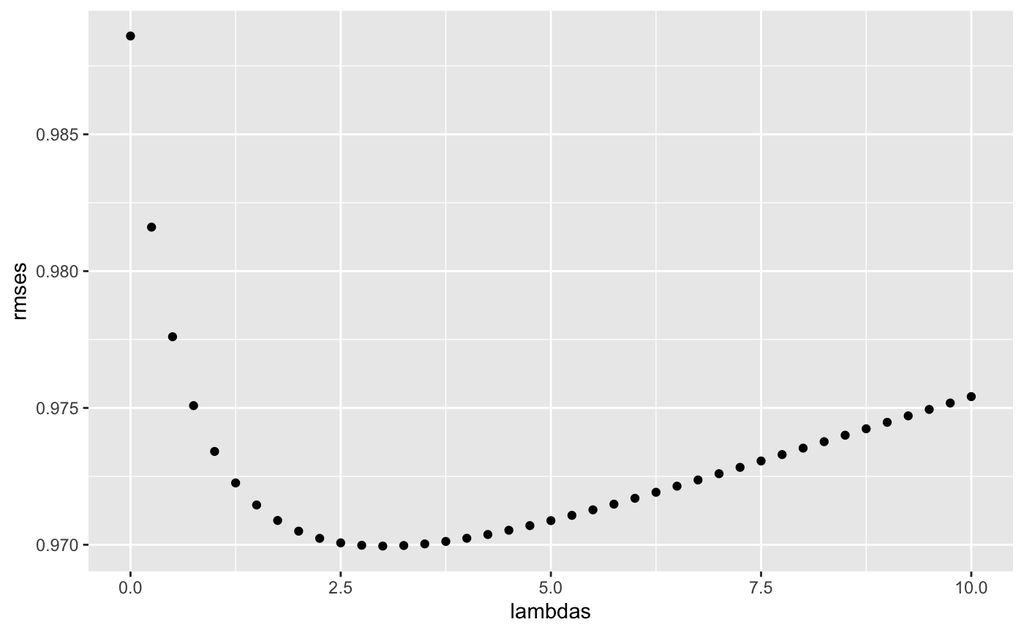

```r
#potential lambdas from 0 to 10 in 0.25 increments
lambdas <- seq(0, 10, 0.25)

just_the_sum <- train_set %>%
  group_by(movieId) %>%
  summarise(s = sum(rating - rating_avg), n_i = n())

rmses <- sapply(lambdas, function(l){
  predicted_ratings <- test_set %>%
    left_join(just_the_sum, by="movieId") %>%
    mutate(b_i = s / (n_i + l)) %>%
    mutate(pred = rating_avg + b_i) %>%
    pull(pred)
  return(RMSE(predicted_ratings, test_set$rating))
})

qplot(lambdas, rmses)
```

```r
lambdas[which.min(rmses)]
```

```
[1] 3
```

lambda = 3 is what minimises RMSE, this is why we chose 3 at the beginning. However, while we show this as an illustration, in practice we should be using full cross-validation just on the train set, without using the test set until the final assessment. The test set should NEVER be used for tuning.

We can use regularization for the estimate user effects as well. We are minimizing:

$$\sum_{u,i} \left(y_{u,i} - \mu - b_i - b_u \right)^2 +
\lambda \left(\sum_{i} b_i^2 + \sum_{u} b_u^2\right)$$

The estimates that minimize this full model can be found similarly to what we did above. Here we use cross-validation to pick a $\lambda$:

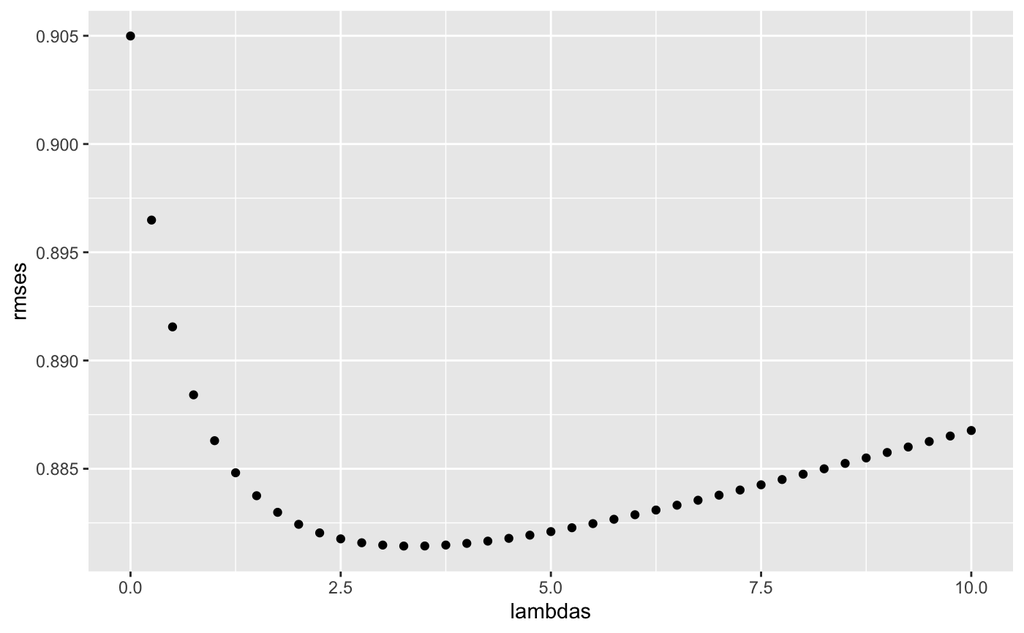

```r
lambdas <- seq(0, 10, 0.25)

rmses <- sapply(lambdas, function(l){

  b_i <- train_set %>%
    group_by(movieId) %>%
    summarise(b_i = sum(rating - rating_avg) / (n() + l))

  b_u <- train_set %>%
    left_join(b_i, by = "movieId") %>%
    group_by(userId) %>%
    summarise(b_u = sum(rating - rating_avg - b_i) / (n() + l))

  predicted_ratings <- test_set %>%
    left_join(b_i, by = "movieId") %>%
    left_join(b_u, by = "userId") %>%
    mutate(pred = rating_avg + b_i + b_u) %>%
    pull(pred)

  return(RMSE(predicted_ratings, test_set$rating))
})

qplot(lambdas, rmses)
```

```r
lambdas[which.min(rmses)]
```

```
[1] 3.25
```

lambda at 3.25 minimises the RMSE for the full model inclusive of user and movie effects.

We can now calculate the RMSE for this regularised full model which is the minimum of all the RMSEs:

```r
min(rmses)
```

```
[1] 0.8814297
```

So our model now reduced the prediction error to 0.88. We can add this to our table:

```r
rmse_results <- bind_rows(rmse_results,
                          tibble(method = "Regularised Movie & User Effect Model",
                                 RMSE = min(rmses)))
rmse_results
```

| method | RMSE |
| --- | --- |
| Naive: Just the Average | 1.0528047 |
| Movie Effect Model | 0.9885931 |
| Movie & User Effects Model | 0.9049899 |
| Regularised Movie Effect Model | 0.9699530 |
| Regularised Movie & User Effect Model | 0.8814297 |

The models above leave out an important source of variation related to the fact that groups of movies have similar rating patterns and groups of users have similar rating patterns as well.

Matrix Factorisation can help with this.

## Matrix Factorisation

This is a widely used concept in ML. It is very much related to factor analysis, singular value decomposition (SVD), and principal component analysis (PCA). Here we describe the concept in the context of movie recommendation systems.

The model we have been using thus far
$$Y_{u,i} = \mu + b_i + b_u + \varepsilon_{u,i}$$
accounts for user and movie effects, but leaves out an important source of variation related to the fact that groups of movies have similar rating patterns and groups of users have similar rating patterns as well. We will discover these patterns by studying the residuals:

$$r_{u,i} = y_{u,i} - \hat{b}_i - \hat{b}_u$$

To see this, we will convert the data into a matrix so that each user gets a row, each movie gets a column, and $y_{u,i}$ is the entry in row $u$ and column $i$. For illustrative purposes, we will only consider a small subset of movies with many ratings and users that have rated many movies. We also keep Scent of a Woman (`movieId == 3252`) because we use it for a specific example:

```r
dim(y)
```

```
[1] 292 455
```

To facilitate exploration, we add row names and column names:

```r
rownames(y) <- y[,1]
y <- y[,-1]

movie_titles <- movielens %>%
  select(movieId, title) %>%
  distinct()

colnames(y) <- with(movie_titles,
                    title[match(colnames(y),
                                movieId)])
```

In order to convert them to residuals, we need to remove the column and row averages (effects):

```r
y <- sweep(y, 2, colMeans(y, na.rm = TRUE))
y <- sweep(y, 2, rowMeans(y, na.rm = TRUE))
```

If the model above explains all the signals, and the $\varepsilon$ are just noise, then the residuals for different movies should be independent from each other. To check we can look at some examples:

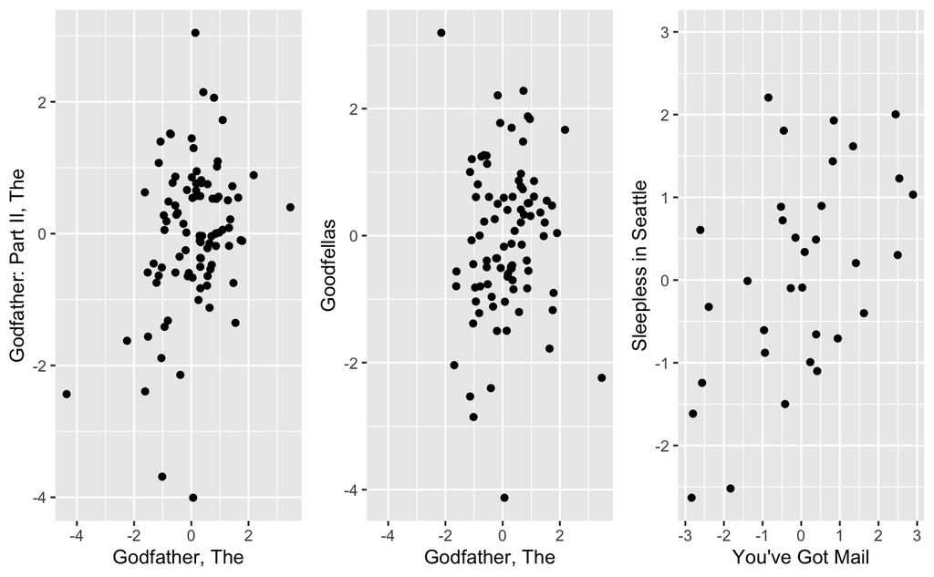

```r
m_1 <- "Godfather, The"
m_2 <- "Godfather: Part II, The"
p1 <- qplot(y[ ,m_1], y[,m_2], xlab = m_1, ylab = m_2)

m_3 <- "Goodfellas"
p2 <- qplot(y[ ,m_1], y[,m_3], xlab = m_1, ylab = m_3)

m_4 <- "You've Got Mail"
m_5 <- "Sleepless in Seattle"
p3 <- qplot(y[ ,m_4], y[,m_5], xlab = m_4, ylab = m_5)

gridExtra::grid.arrange(p1, p2 ,p3, ncol = 3)
```

We can see from the plots that the residuals are not independent but correlated. The first plot shows that users that liked The Godfather more than what the model expects them to, based on the movie and user effects, also liked The Godfather II more than expected. A similar relationship is seen when comparing The Godfather and Goodfellas. Although not as strong, there is still correlation. We see correlations between You’ve Got Mail and Sleepless in Seattle as well.

We can pairwise correlation to check:

```r
cor(y[, c(m_1, m_2, m_3, m_4, m_5)],
    use = "pairwise.complete")
```

```
                        Godfather, The Godfather: Part II, The Goodfellas You've Got Mail Sleepless in Seattle
Godfather, The             1.000000000               0.3086762  0.0585488     -0.07180218          0.001619366
Godfather: Part II, The    0.308676186               1.0000000  0.3195368     -0.13590338         -0.225878638
Goodfellas                 0.058548799               0.3195368  1.0000000     -0.57051042         -0.246132185
You've Got Mail           -0.071802183              -0.1359034 -0.5705104      1.00000000          0.521131872
Sleepless in Seattle       0.001619366              -0.2258786 -0.2461322      0.52113187          1.000000000
```

We can see a positive correlation between gangster movies and positive correlation among romantic comedies. We also see a negative correlation between the two genres.

The result tells us there is a structure in the data that the model doesn’t account for. So how can we model this?

Here we use matrix factorisation.

### Factor Analysis

We want to predict the residuals $r_{u,i}$ using some structure. Here is a simulation to illustrate the idea.

Suppose our residuals ‘r’ look like this where we create a vector q that assigns 1 to gangster movies and -1 to romantic comedies. We also create a vector p that reduces the users to three types: those that like gangster movies and dislike romantic comedies (coded as 2), those that like romcoms but dislike gangster movies (coded as -2), and those that don’t care (coded as 0).

```r
round(r, 1)
```

```
   Godfather, The Godfather: Part II, The Goodfellas You've Got Mail Sleepless in Seattle
1             2.0                     2.3        2.2            -1.8                 -1.9
2             2.0                     1.7        2.0            -1.9                 -1.7
3             1.9                     2.4        2.1            -2.3                 -2.0
4            -0.3                     0.3        0.3            -0.4                 -0.3
5            -0.3                    -0.4        0.3             0.2                  0.3
6            -0.1                     0.1        0.2            -0.3                  0.2
7            -0.1                     0.0       -0.2            -0.2                  0.3
8             0.2                     0.2        0.1             0.0                  0.4
9            -1.7                    -2.1       -1.8             2.0                  2.4
10           -2.3                    -1.8       -1.7             1.8                  1.7
11           -1.7                    -2.0       -2.1             1.9                  2.3
12           -1.8                    -1.7       -2.1             2.3                  2.0
```

There seems to be a pattern in this simulation which is based on what we saw with real data. There is a gangster movie effect and there is a romantic comedy effect. we can check the correlation patterns:

```r
cor(r)
```

```
                        Godfather, The Godfather: Part II, The Goodfellas You've Got Mail Sleepless in Seattle
Godfather, The               1.0000000               0.9803263  0.9777825      -0.9740312           -0.9657734
Godfather: Part II, The      0.9803263               1.0000000  0.9833056      -0.9866056           -0.9917416
Goodfellas                   0.9777825               0.9833056  1.0000000      -0.9864329           -0.9885380
You've Got Mail             -0.9740312              -0.9866056 -0.9864329       1.0000000            0.9855309
Sleepless in Seattle        -0.9657734              -0.9917416 -0.9885380       0.9855309            1.0000000
```

The main point here is that we can almost reconstruct r, which has 60 values (12 x 5), with two vectors totaling 17 values (q has 5 values and p has 12). These two vectors can be used to form the matrix with with 60 values instead.

If $r$ contains the residuals for users $u=1,\dots,12$ for movies $i=1,\dots,5$ we can write the following mathematical formula for our residuals $r_{u,i}$.

$$r_{u,i} \approx p_u q_i$$

This implies that we can explain more variability by modifying our previous model for movie recommendations to:

$$Y_{u,i} = \mu + b_i + b_u + p_u q_i + \varepsilon_{u,i}$$

However, we motivated the need for the $p_u q_i$ term with a simple simulation. The structure found in data is usually more complex. For example, in this first simulation we assumed there were was just one factor $p_u$ that determined which of the two genres movie $u$ belongs to. But the structure in our movie data seems to be much more complicated than gangster movie versus romance. We may have many other factors. Here we present a slightly more complex simulation. We now add a sixth movie.

```r
set.seed(1988)

m_6 <- "Scent of a Woman"
q <- cbind(c(1 , 1, 1, -1, -1, -1),
           c(1 , 1, -1, -1, -1, 1))
rownames(q) <- c(m_1, m_2, m_3, m_4, m_5, m_6)
p <- cbind(rep(c(2,0,-2), c(3,5,4)),
          c(-1,1,1,0,0,1,1,1,0,-1,-1,-1))/2
rownames(p) <- 1:nrow(p)

r <- jitter(p %*% t(q), factor=1)

round(r, 1)
```

```
   Godfather, The Godfather: Part II, The Goodfellas You've Got Mail Sleepless in Seattle Scent of a Woman
1             0.5                     0.6        1.6            -0.5                 -0.5             -1.6
2             1.5                     1.4        0.5            -1.5                 -1.4             -0.4
3             1.5                     1.6        0.5            -1.6                 -1.5             -0.5
4            -0.1                     0.1        0.1            -0.1                 -0.1              0.1
5            -0.1                    -0.1        0.1             0.0                  0.1             -0.1
6             0.5                     0.5       -0.4            -0.6                 -0.5              0.5
7             0.5                     0.5       -0.5            -0.6                 -0.4              0.4
8             0.5                     0.6       -0.5            -0.5                 -0.4              0.4
9            -0.9                    -1.0       -0.9             1.0                  1.1              0.9
10           -1.6                    -1.4       -0.4             1.5                  1.4              0.5
11           -1.4                    -1.5       -0.5             1.5                  1.6              0.6
12           -1.4                    -1.4       -0.5             1.6                  1.5              0.6
```

We can see another factor - a factor that divides users into those that love, hate, or don’t care for Al Pacino. We can see this complication in the correlation structure:

```r
cor(r)
```

```
                        Godfather, The Godfather: Part II, The Goodfellas You've Got Mail Sleepless in Seattle
Godfather, The               1.0000000               0.9973680  0.5619427      -0.9968137           -0.9955408
Godfather: Part II, The      0.9973680               1.0000000  0.5770328      -0.9983198           -0.9989206
Goodfellas                   0.5619427               0.5770328  1.0000000      -0.5519540           -0.5831845
You've Got Mail             -0.9968137              -0.9983198 -0.5519540       1.0000000            0.9983286
Sleepless in Seattle        -0.9955408              -0.9989206 -0.5831845       0.9983286            1.0000000
Scent of a Woman            -0.5712246              -0.5833762 -0.9940376       0.5581798            0.5875136
                        Scent of a Woman
Godfather, The                -0.5712246
Godfather: Part II, The       -0.5833762
Goodfellas                    -0.9940376
You've Got Mail                0.5581798
Sleepless in Seattle           0.5875136
Scent of a Woman               1.0000000
```

We note that we perhaps need a second factor to account for the fact that some users like Al Pacino, while others dislike him or don’t care. Notice that the overall structure of the correlation obtained from the simulated data is not that far off the real correlation:

```r
x <- y[ , c(m_1, m_2, m_3, m_4, m_5, m_6)]
cor(x, use = "pairwise.complete")
```

```
                        Godfather, The Godfather: Part II, The Goodfellas You've Got Mail Sleepless in Seattle
Godfather, The             1.000000000               0.3086762  0.0585488     -0.07180218          0.001619366
Godfather: Part II, The    0.308676186               1.0000000  0.3195368     -0.13590338         -0.225878638
Goodfellas                 0.058548799               0.3195368  1.0000000     -0.57051042         -0.246132185
You've Got Mail           -0.071802183              -0.1359034 -0.5705104      1.00000000          0.521131872
Sleepless in Seattle       0.001619366              -0.2258786 -0.2461322      0.52113187          1.000000000
Scent of a Woman           0.018305446               0.2967934  0.4004337     -0.09117243          0.037563269
                        Scent of a Woman
Godfather, The                0.01830545
Godfather: Part II, The       0.29679343
Goodfellas                    0.40043367
You've Got Mail              -0.09117243
Sleepless in Seattle          0.03756327
Scent of a Woman              1.00000000
```

To explain the structure we need two factors:

```r
t(q)
```

```
     Godfather, The Godfather: Part II, The Goodfellas You've Got Mail Sleepless in Seattle Scent of a Woman
[1,]              1                       1          1              -1                   -1               -1
[2,]              1                       1         -1              -1                   -1                1
```

With the first factor (the first row) used to code the gangster versus romance groups and a second factor (the second row) to explain the Al Pacino versus no Al Pacino groups. We will also need two sets of coefficients to explain the variability introduced by the $3\times 3$ types of groups:

```r
t(p)
```

```
        1   2   3 4 5   6   7   8  9   10   11   12
[1,]  1.0 1.0 1.0 0 0 0.0 0.0 0.0 -1 -1.0 -1.0 -1.0
[2,] -0.5 0.5 0.5 0 0 0.5 0.5 0.5  0 -0.5 -0.5 -0.5
```

The model with two factors has 36 parameters (q has 12, p has 24) that can be used to explain much of the variability in the 72 ratings:

$$Y_{u,i} = \mu + b_i + b_u + p_{u,1} q_{1,i} + p_{u,2} q_{2,i} +
\varepsilon_{u,i}$$

Note that in an actual data application, we need to fit this model to data. To explain the complex correlation we observe in real data, we usually permit the entries of $p$ and $q$ to be continuous values, rather than discrete ones as we used in the simulation. For example, rather than dividing movies into gangster or romance, we define a continuum.

Also note that this is not a linear model and to fit it we need to use an algorithm other than the one used by `lm` to find the parameters that minimize the least squares. The winning algorithms for the Netflix challenge fit a model similar to the above and used regularization to penalize for large values of $p$ and $q$, rather than using least squares, in addition to penalising user and movie effects. However, implementing this approach is beyond this project (and beyond the “Introduction to Data Science Book”).

In reality, if we want to find the structure using the data as opposed to constructing it ourselves as we just did, we need to fit the models to data. This means we need to figure out how to estimate factors from the data as opposed to defining ourselves.

One way to do this is to fit models, but we can also use Principal Component Analysis (PCA) or equivalently the Singular Value Decomposition (SVD) to estimates factors from data.

### Singular Value Decomposition (SVD) and Principal Component Analysis (PCA)

The matrix decomposition:

$$r_{u,i} \approx p_{u,1} q_{1,i} + p_{u,2} q_{2,i}$$

is very much related to SVD and PCA. SVD and PCA are complicated concepts, but one way to understand them is that SVD is an algorithm that finds the vectors $p$ and $q$ that permit us to rewrite the matrix $\mbox{r}$ with $m$ rows and $n$ columns as:

$$r_{u,i} = p_{u,1} q_{1,i} + p_{u,2} q_{2,i} + \dots + p_{u,n} q_{n,i}$$

with the variability of each term decreasing and with the $p$s uncorrelated. The algorithm also computes this variability so that we can know how much of the matrices, total variability is explained as we add new terms. This may permit us to see that, with just a few terms, we can explain most of the variability.

Let’s see an example with the movie data. To compute the decomposition, we will make the residuals with NAs equal to 0:

```r
y[is.na(y)] <- 0
pca <- prcomp(y)
```

The $q$ vectors are called the principal components and they are stored in this matrix:

```r
dim(pca$rotation)
```

[output not shown]

While the $p$, or the user effects, are here:

```r
dim(pca$x)
```

```
[1] 292 292
```

We can see the variability of each of the vectors:

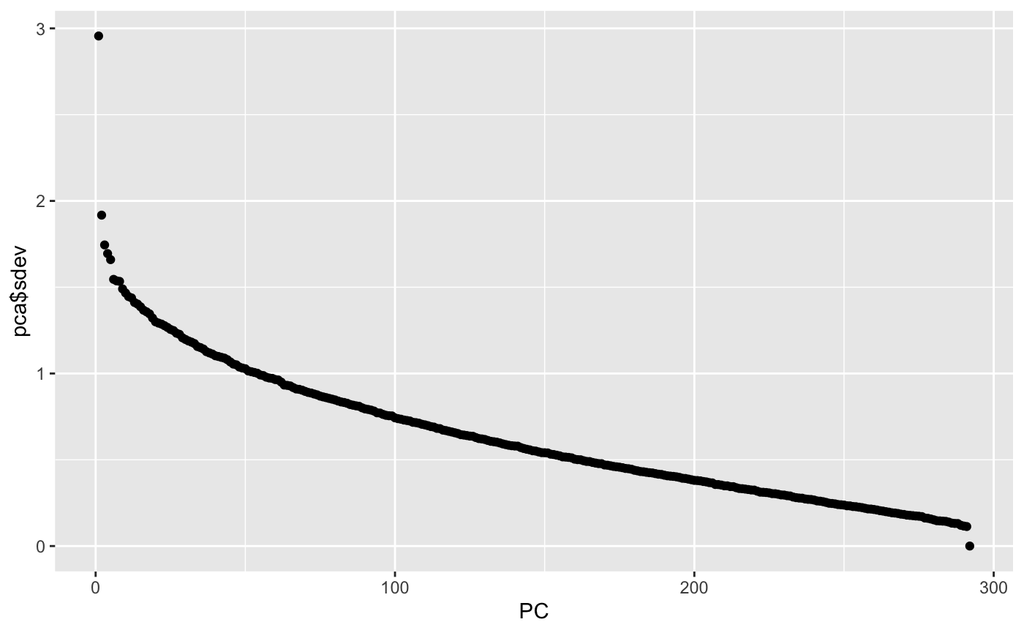

```r
qplot(1:nrow(x),
      pca$sdev,
      xlab = "PC")
```

and we can see that the first few principal components explain a large percent:

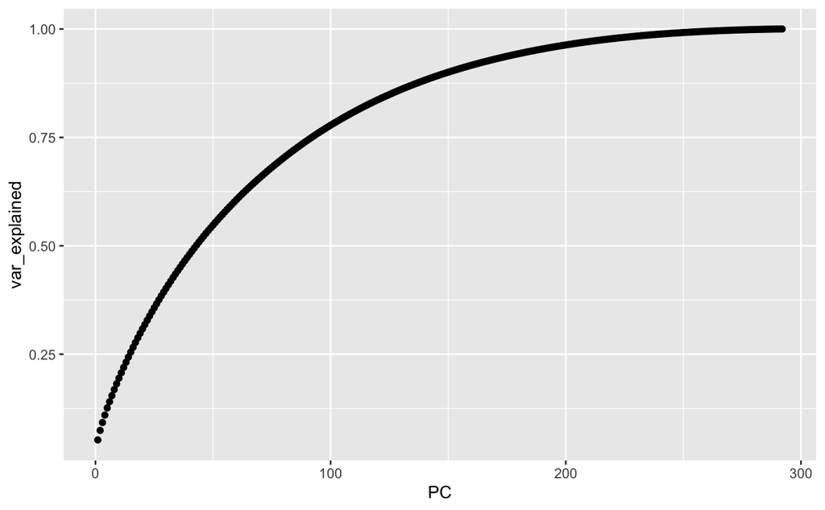

```r
#var explained PCA

var_explained <- cumsum(pca$sdev^2 / sum(pca$sdev^2))
qplot(1:nrow(x), var_explained, xlab = "PC")
```

We also notice that the first two principal components are related to the structure in opinions about movies:

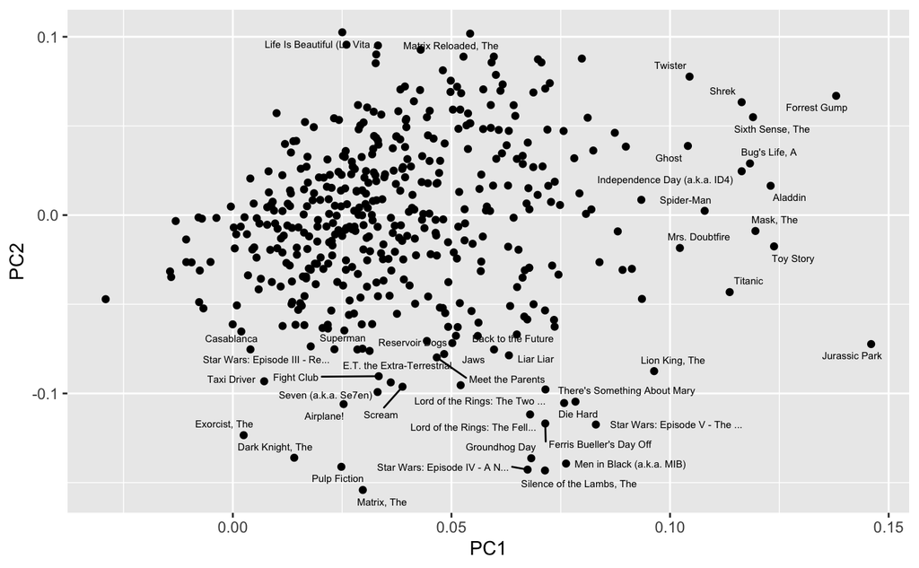

```r
pcs <- data.frame(pca$rotation,
                  name = str_trunc(colnames(y),
                                   30),
                  stringsAsFactors = FALSE)

highlight <- filter(pcs, PC1 < -0.1 | PC1 > 0.1 | PC2 < -0.075 | PC2 > 0.1)

pcs %>% ggplot(aes(PC1, PC2)) +
  geom_point() + geom_text_repel(aes(PC1, PC2, label = name),
                                 data = highlight,
                                 size = 2)
```

Just by looking at the top 10 in each direction, we see a meaningful pattern. The first PC shows the difference between critically acclaimed movies on one side:

```r
#10 worst movies

pcs %>%
  select(name, PC1) %>%
  arrange(PC1) %>%
  slice(1:10) %>%
  pull(name)
```

```
 [1] "Clockwork Orange, A"            "Eyes Wide Shut"                 "Species"
 [4] "Maltese Falcon, The"            "Leaving Las Vegas"              "Seven Samurai (Shichinin no..."
 [7] "Star Trek"                      "Inception"                      "Manhattan"
[10] "Pleasantville"
```

and Hollywood blockbusters on the other:

```r
pcs %>%
  select(name, PC1) %>%
  arrange(desc(PC1)) %>%
  slice(1:10) %>%
  pull(name)
```

```
 [1] "Jurassic Park"                 "Forrest Gump"                  "Toy Story"
 [4] "Aladdin"                       "Mask, The"                     "Sixth Sense, The"
 [7] "Bug's Life, A"                 "Independence Day (a.k.a. ID4)" "Shrek"
[10] "Titanic"
```

```r
pcs %>%
  select(name, PC2) %>%
  arrange(PC2) %>%
  slice(1:10) %>%
  pull(name)
```

```
 [1] "Matrix, The"                    "Silence of the Lambs, The"      "Star Wars: Episode IV - A N..."
 [4] "Pulp Fiction"                   "Men in Black (a.k.a. MIB)"      "Groundhog Day"
 [7] "Dark Knight, The"               "Exorcist, The"                  "Star Wars: Episode V - The ..."
[10] "Ferris Bueller's Day Off"
```

```r
pcs %>%
  select(name, PC2) %>%
  arrange(desc(PC2)) %>%
  slice(1:10) %>%
  pull(name)
```

```
 [1] "Life Is Beautiful (La Vita ..." "Matrix Reloaded, The"           "Like Water for Chocolate (C..."
 [4] "Blues Brothers, The"            "Little Miss Sunshine"           "Kill Bill: Vol. 2"
 [7] "Lock, Stock & Two Smoking B..." "Lost World: Jurassic Park, The" "Ransom"
[10] "You've Got Mail"
```

So, using PCA, we’ve shown that a matrix factorisation approach can find important structure in our data.

To actually fit the matrix factorisation model that has been presented earlier that takes into account that there is missing data, that there is missing cells in the matrix, is a bit more complicated. For those interested in implementing that incorporates these ideas, **recommenderlab** package can be used.